# Project1

Erica Laughlin

July 28, 2017

First I need to load required packages, then download, unzip, and read the data.

```r
library(knitr)
library(dplyr)
```

```r
library(ggplot2)
library(downloader)
library(tidyr)
library(mice)
download("https://d396qusza40orc.cloudfront.net/repdata%2Fdata%2Factivity.zip", dest="activity.zip", mode = "wb")
unzip("activity.zip")
activity <- read.csv("activity.csv")
```

Exploring the data a little.

```r
dim(activity)
```

```
## [1] 17568     3
```

```r
head(activity)
```

```
##   steps       date interval
## 1    NA 2012-10-01        0
## 2    NA 2012-10-01        5
## 3    NA 2012-10-01       10
## 4    NA 2012-10-01       15
## 5    NA 2012-10-01       20
## 6    NA 2012-10-01       25
```

```r
summary(activity)
```

```
##      steps                date          interval
##  Min.   :  0.00   2012-10-01:  288   Min.   :   0.0
##  1st Qu.:  0.00   2012-10-02:  288   1st Qu.: 588.8
##  Median :  0.00   2012-10-03:  288   Median :1177.5
##  Mean   : 37.38   2012-10-04:  288   Mean   :1177.5
##  3rd Qu.: 12.00   2012-10-05:  288   3rd Qu.:1766.2
##  Max.   :806.00   2012-10-06:  288   Max.   :2355.0
##  NA's   :2304     (Other)   :15840
```

Generating a histogram of total daily steps taken.

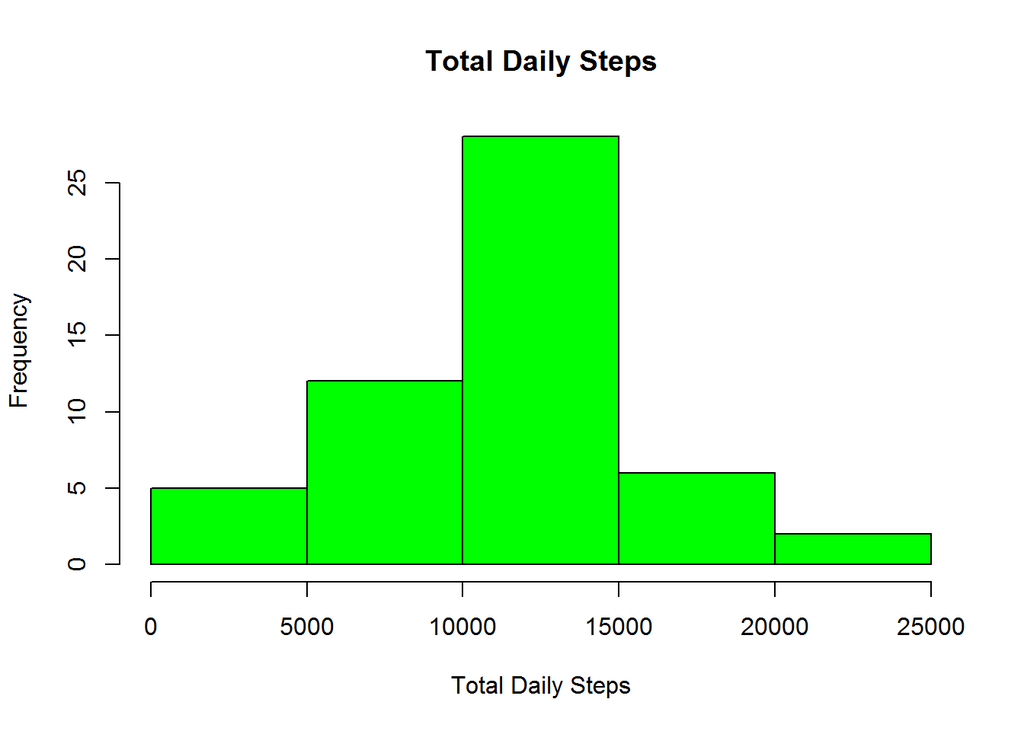

```r
activity$date <- as.factor(activity$date)
stepsbydate <- group_by(activity, date) %>%
  summarize(total_steps = sum(steps))
hist(stepsbydate$total_steps, main = "Total Daily Steps", xlab = "Total Daily Steps", col = "green")
```

The histogram shows us that our subject most frequently took between 10,000 and 15,000 steps in a day. Calculating the mean and median measurements for total daily steps.

```r
mean(stepsbydate$total_steps, na.rm = TRUE)
```

```
## [1] 10766.19
```

```r
median(stepsbydate$total_steps, na.rm = TRUE)
```

```
## [1] 10765
```

This validates our earlier finding. The average number of steps taken in a day is about 10,766. Next I’m going to create a version of the dataframe with missing values removed, and then generate a time series plot of the average number of steps taken.

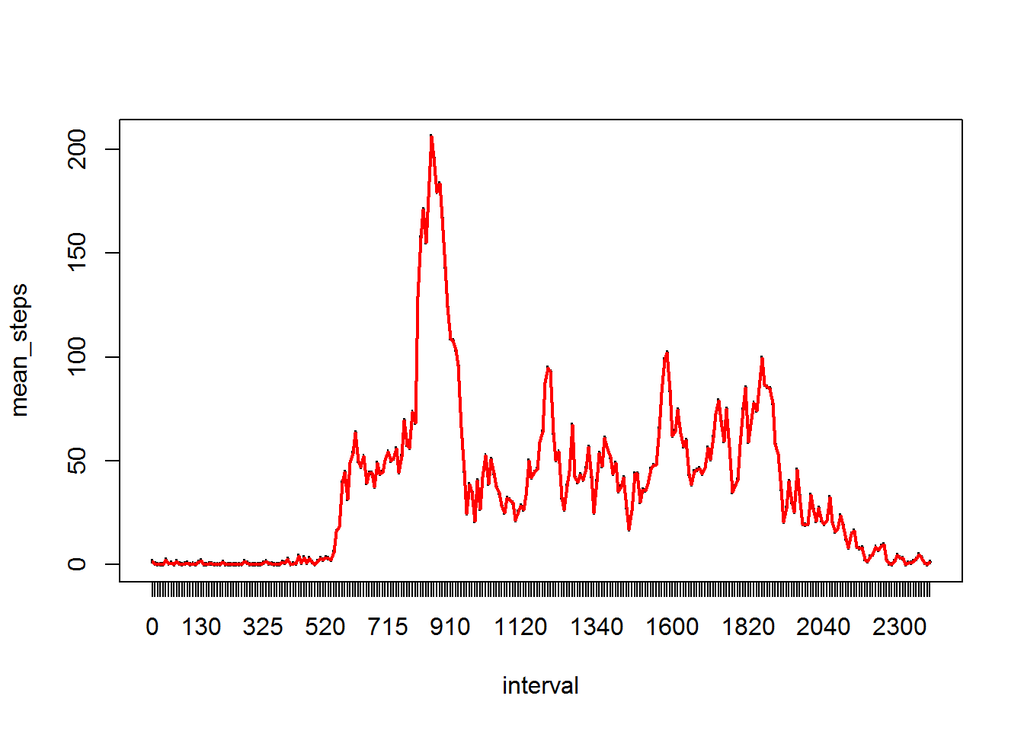

```r
activity$interval <- as.factor(activity$interval)
activity2 <- na.omit(activity)
stepsbyint <- group_by(activity2, interval) %>%
  summarize(mean_steps = mean(steps))
plot(stepsbyint)
lines(stepsbyint, lwd = 2, col = "red")
```

There is a tall peak in the data that occurs sometime in the morning. Now I’m going to determine which exact 5-minute interval has the highest average number of steps taken.

```r
highestmean <- max(stepsbyint$mean_steps)
subset(stepsbyint, mean_steps == highestmean)
```

```
## # A tibble: 1 x 2
##   interval mean_steps
##     <fctr>      <dbl>
## 1      835   206.1698
```

Looks like, on average, the highest average number of steps taken is at 8:35 AM each day, with an average of about 206 steps taken. Now, I’m going to create a version of the data frame that imputes missing data with predictive mean matching using the mice package.

```r
ini <- mice(activity, maxit=0, pri=F)
pred <- ini$pred
pred[, "date"] <- 0
imp <- mice(activity, m=1, maxit=1, pred=pred)
imp
```

```
## Multiply imputed data set
## Call:
## mice(data = activity, m = 1, predictorMatrix = pred, maxit = 1)
## Number of multiple imputations:  1
## Missing cells per column:
##    steps     date interval
##     2304        0        0
## Imputation methods:
##    steps     date interval
##    "pmm"       ""       ""
## VisitSequence:
## steps
##     1
## PredictorMatrix:
##          steps date interval
## steps        0    0        1
## date         0    0        0
## interval     0    0        0
## Random generator seed value:  NA
```

Let’s take a look at the first 100 lines of the new dataset.

```r
activity3 <- complete(imp)
head(activity3, n=100)
```

```
##     steps       date interval
## 1       0 2012-10-01        0
## 2      12 2012-10-01        5
## 3       0 2012-10-01       10
## 4       0 2012-10-01       15
## 5       0 2012-10-01       20
## 6       0 2012-10-01       25
## 7       0 2012-10-01       30
## 8       0 2012-10-01       35
## 9       0 2012-10-01       40
## 10      0 2012-10-01       45
## 11      0 2012-10-01       50
## 12      0 2012-10-01       55
## 13      0 2012-10-01      100
## 14      0 2012-10-01      105
```

[output cut: 86 more lines]

Generating a new histogram of total daily steps taken, now with imputed values. Calculating mean and median.

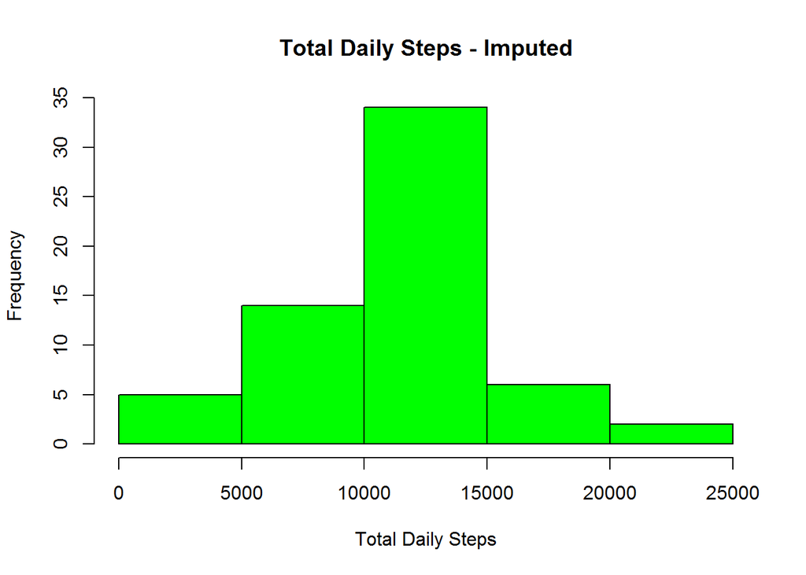

```r
stepsbydate2 <- group_by(activity3, date) %>%
  summarize(total_steps = sum(steps))
hist(stepsbydate2$total_steps, main = "Total Daily Steps - Imputed", xlab = "Total Daily Steps", col = "green")
```

```r
mean(stepsbydate2$total_steps, na.rm = TRUE)
```

```
## [1] 10664.89
```

```r
median(stepsbydate2$total_steps, na.rm = TRUE)
```

```
## [1] 10600
```